# salaries

Random Forest is an ensemble technique capable of performing both regression and classification tasks with the use of multiple decision trees and a technique called Bootstrap and Aggregation, commonly known as bagging. The basic idea behind this is to combine multiple decision trees in determining the final output rather than relying on individual decision trees.

Random Forest has multiple decision trees as base learning models. We randomly perform row sampling and feature sampling from the dataset forming sample datasets for every model

We need to approach the Random Forest regression technique like any other machine learning technique

Design a specific question or data and get the source to determine the required data. Make sure the data is in an accessible format else convert it to the required format. Specify all noticeable anomalies and missing data points that may be required to achieve the required data. Create a machine-learning model. Set the baseline model that you want to achieve Train the data machine learning model. Provide an insight into the model with test data Now compare the performance metrics of both the test data and the predicted data from the model. If it doesn’t satisfy your expectations, you can try improving your model accordingly or dating your data, or using another data modeling technique. At this stage, you interpret the data you have gained and report accordingly. You will be using a similar sample technique in the below example.

Here is the Dataset: https://bit.ly/417n3N5

```python
# Importing the libraries
import numpy as np
import matplotlib.pyplot as plt
import pandas as pd
#import radomforest
from sklearn.ensemble import RandomForestRegressor
```

```python
#read the Dateset from the folder named Position_Salaries.csv
dataset = pd.read_csv('Position_Salaries.csv')

#print the first 5 rows of the dataset
dataset.head()
```

|  | Position | Level | Salary |
| --- | --- | --- | --- |
| 0 | Business Analyst | 1 | 45000 |
| 1 | Junior Consultant | 2 | 50000 |
| 2 | Senior Consultant | 3 | 60000 |
| 3 | Manager | 4 | 80000 |
| 4 | Country Manager | 5 | 110000 |

```python
#check the shape of the dataset
dataset.shape
```

```
(10, 3)
```

```python
#check the Null values in the dataset
dataset.isnull().sum()
```

```
Position    0
Level       0
Salary      0
dtype: int64
```

```python
# Select all rows and column 1 from dataset to x and all rows and column 2 as y

"""
 the “iloc()” function enables us
to select a particular cell of the dataset, that is,
 it helps us select a value that belongs to a
 particular row or column from a set of values of a data frame or dataset.
"""
x = dataset.iloc[:, 1:2].values
y = dataset.iloc[:, 2].values


#print the selected rows and columns
print(x)
print(y)
```

```
[[ 1]
 [ 2]
 [ 3]
 [ 4]
 [ 5]
 [ 6]
 [ 7]
 [ 8]
 [ 9]
 [10]]
[  45000   50000   60000   80000  110000  150000  200000  300000  500000
 1000000]
```

```python
#initialize the random forest regressor
regressor = RandomForestRegressor(n_estimators = 10, random_state = 0)
```

```python
#fit the model  with x and y
regressor.fit(x, y)
```

```
RandomForestRegressor(n_estimators=10, random_state=0)
```

```python
#predict the model
Y_pred = regressor.predict(np.array([6.5]).reshape(1, 1))  # test the output by changing values

#print the accuracy of the model
print("Accuracy:",regressor.score(x,y)*100)
```

```
Accuracy: 97.04434230386582
```

```python
import numpy
print(numpy.__version__)
```

```
1.23.5
```

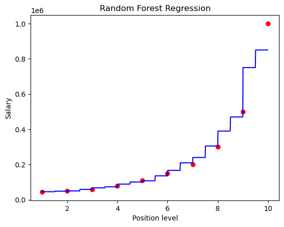

```python
#visualize the graph
x_grid = np.arange(min(x), max(x), 0.01)
x_grid = x_grid.reshape((len(x_grid), 1))
plt.scatter(x, y, color = 'red')
plt.plot(x_grid, regressor.predict(x_grid), color = 'blue')
plt.title('Random Forest Regression')
plt.xlabel('Position level')
plt.ylabel('Salary')
plt.show()
```

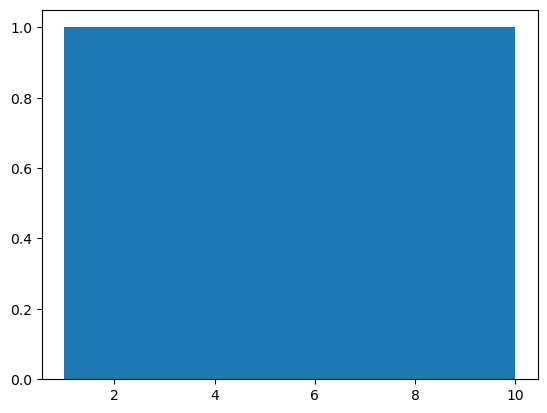

```python
#plot a histogram
plt.hist(x)
plt.show()
```

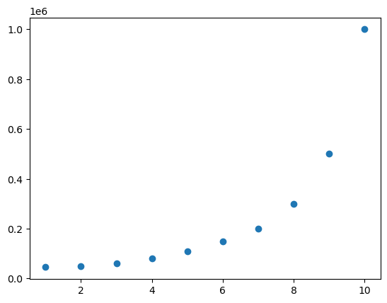

```python
#plot a scatter plot
plt.scatter(x,y)
plt.show()
```

```python
print("FROM KIASH SOLUTIONS KEEP LEARNING AND KEEP SHARING")
```

[output not shown]